# 城市气候与海洋的关系研究

导入包

```python
import numpy as np
import pandas as pd
from pandas import Series,DataFrame
import matplotlib.pyplot as plt
%matplotlib inline
```

导入数据各个海滨城市数据

```python
ferrara1 = pd.read_csv('./ferrara_150715.csv')
ferrara2 = pd.read_csv('./ferrara_250715.csv')
ferrara3 = pd.read_csv('./ferrara_270615.csv')
ferrara = pd.concat([ferrara1,ferrara2,ferrara3],ignore_index=True)
```

```python
torino1 = pd.read_csv('./torino_150715.csv')
torino2 = pd.read_csv('./torino_250715.csv')
torino3 = pd.read_csv('./torino_270615.csv')
torino = pd.concat([torino1,torino2,torino3],ignore_index=True)
```

```python
mantova1 = pd.read_csv('./mantova_150715.csv')
mantova2 = pd.read_csv('./mantova_250715.csv')
mantova3 = pd.read_csv('./mantova_270615.csv')
mantova = pd.concat([mantova1,mantova2,mantova3],ignore_index=True)
```

```python
milano1 = pd.read_csv('./milano_150715.csv')
milano2 = pd.read_csv('./milano_250715.csv')
milano3 = pd.read_csv('./milano_270615.csv')
milano = pd.concat([milano1,milano2,milano3],ignore_index=True)
```

```python
ravenna1 = pd.read_csv('./ravenna_150715.csv')
ravenna2 = pd.read_csv('./ravenna_250715.csv')
ravenna3 = pd.read_csv('./ravenna_270615.csv')
ravenna = pd.concat([ravenna1,ravenna2,ravenna3],ignore_index=True)
```

```python
asti1 = pd.read_csv('./asti_150715.csv')
asti2 = pd.read_csv('./asti_250715.csv')
asti3 = pd.read_csv('./asti_270615.csv')
asti = pd.concat([asti1,asti2,asti3],ignore_index=True)
```

```python
bologna1 = pd.read_csv('./bologna_150715.csv')
bologna2 = pd.read_csv('./bologna_250715.csv')
bologna3 = pd.read_csv('./bologna_270615.csv')
bologna = pd.concat([bologna1,bologna2,bologna3],ignore_index=True)
```

```python
piacenza1 = pd.read_csv('./piacenza_150715.csv')
piacenza2 = pd.read_csv('./piacenza_250715.csv')
piacenza3 = pd.read_csv('./piacenza_270615.csv')
piacenza = pd.concat([piacenza1,piacenza2,piacenza3],ignore_index=True)
```

```python
cesena1 = pd.read_csv('./cesena_150715.csv')
cesena2 = pd.read_csv('./cesena_250715.csv')
cesena3 = pd.read_csv('./cesena_270615.csv')
cesena = pd.concat([cesena1,cesena2,cesena3],ignore_index=True)
```

```python
faenza1 = pd.read_csv('./faenza_150715.csv')
faenza2 = pd.read_csv('./faenza_250715.csv')
faenza3 = pd.read_csv('./faenza_270615.csv')
faenza = pd.concat([faenza1,faenza2,faenza3],ignore_index=True)
faenza.head()
```

|  | Unnamed: 0 | temp | humidity | pressure | description | dt | wind_speed | wind_deg | city | day | dist |
| --- | --- | --- | --- | --- | --- | --- | --- | --- | --- | --- | --- |
| 0 | 0 | 29.40 | 83 | 1015 | moderate rain | 1436863177 | 3.62 | 94.001 | Faenza | 2015-07-14 10:39:37 | 37 |
| 1 | 1 | 30.12 | 78 | 1015 | moderate rain | 1436866759 | 3.10 | 80.000 | Faenza | 2015-07-14 11:39:19 | 37 |
| 2 | 2 | 30.10 | 78 | 1015 | moderate rain | 1436870510 | 3.60 | 70.000 | Faenza | 2015-07-14 12:41:50 | 37 |
| 3 | 3 | 30.75 | 74 | 1015 | moderate rain | 1436874099 | 4.60 | 90.000 | Faenza | 2015-07-14 13:41:39 | 37 |
| 4 | 4 | 30.71 | 66 | 1015 | moderate rain | 1436877646 | 5.10 | 100.000 | Faenza | 2015-07-14 14:40:46 | 37 |

去除没用的列

```python
ferrara.drop('Unnamed: 0',axis=1,inplace=True)
torino.drop('Unnamed: 0',axis=1,inplace=True)
mantova.drop('Unnamed: 0',axis=1,inplace=True)
milano.drop('Unnamed: 0',axis=1,inplace=True)
ravenna.drop('Unnamed: 0',axis=1,inplace=True)
asti.drop('Unnamed: 0',axis=1,inplace=True)
bologna.drop('Unnamed: 0',axis=1,inplace=True)
piacenza.drop('Unnamed: 0',axis=1,inplace=True)
faenza.drop('Unnamed: 0',axis=1,inplace=True)
```

显示最高温度与离海远近的关系

```python
faenza.dist
```

```
0     37
1     37
2     37
3     37
4     37
5     37
6     37
7     37
8     37
9     37
10    37
11    37
12    37
13    37
14    37
```

[output cut: 47 more lines]

```python
city_list = [ferrara,torino,mantova,milano,ravenna,asti,bologna,piacenza,faenza]
```

```python
dist = [city['dist'][0] for city in city_list]
dist
```

```
[47, 357, 121, 250, 8, 315, 71, 200, 37]
```

```python
max_temp = [city['temp'].max() for city in city_list]
max_temp
```

```
[33.43000000000001,
 34.69,
 34.18000000000001,
 34.81,
 32.79000000000002,
 34.31,
 33.850000000000016,
 33.920000000000016,
 32.74000000000001]
```

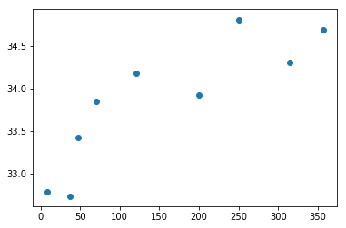

```python
x = np.array(dist)
y = np.array(max_temp)

plt.scatter(x,y)
```

观察发现，离海近的可以形成一条直线，离海远的也能形成一条直线。

首先使用numpy：把列表转换为numpy数组，用于后续计算。

分别以100公里和50公里为分界点，划分为离海近和离海远的两组数据

```python
max_temp = np.array(max_temp)
```

```python
dist = np.array(dist)
```

```python
dist
```

```
array([ 47, 357, 121, 250,   8, 315,  71, 200,  37], dtype=int64)
```

```python
far_city = dist>50
near_city = dist<100
```

```python
near_dist = dist[near_city]
near_temp = max_temp[near_city]

far_dist = dist[far_city]
far_temp = max_temp[far_city]
```

```python
display(near_dist,near_temp)
display(far_dist,far_temp)
```

```
array([47,  8, 71, 37], dtype=int64)
```

```
array([33.43, 32.79, 33.85, 32.74])
```

```
array([357, 121, 250, 315,  71, 200], dtype=int64)
```

```
array([34.69, 34.18, 34.81, 34.31, 33.85, 33.92])
```

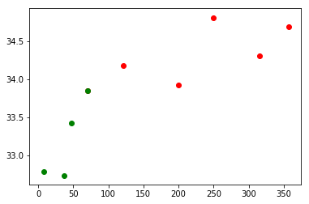

```python
plt.scatter(far_dist,far_temp,color='red')
plt.scatter(near_dist,near_temp,color='green')
```

```python
# 机器学习 线性回归模型
# scikit-learn
from sklearn.linear_model import LinearRegression
```

```python
# 相当于假设一种函数关系
# f(x) = wx+b
# x**2 + y**2 = R
linear = LinearRegression()
# 优化算法，找到最优解（误差最小的函数表达）
```

```python
# 训练模型
# 距离可以认为是自变量
# 温度认为是因变量
```

```python
# 一个被训练过的模型，就是一个预测函数表达式f(x) = wx+b
linear.fit(near_dist.reshape(-1,1),near_temp)
```

```
LinearRegression(copy_X=True, fit_intercept=True, n_jobs=1, normalize=False)
```

```python
# 预测  利用估计函数进行求解
linear.predict([[71],[32],[35],[56]])
```

```
array([33.73987015, 33.04706235, 33.10035526, 33.47340561])
```

```python
xmin,xmax = near_dist.min(),near_dist.max()+10
x = np.linspace(xmin,xmax,100).reshape(-1,1)
x
```

```
array([[ 8.        ],
       [ 8.73737374],
       [ 9.47474747],
       [10.21212121],
       [10.94949495],
       [11.68686869],
       [12.42424242],
       [13.16161616],
       [13.8989899 ],
       [14.63636364],
       [15.37373737],
       [16.11111111],
       [16.84848485],
       [17.58585859],
       [18.32323232],
       [19.06060606],
       [19.7979798 ],
       [20.53535354],
       [21.27272727],
       [22.01010101],
       [22.74747475],
       [23.48484848],
       [24.22222222],
       [24.95959596],
       [25.6969697 ],
       [26.43434343],
       [27.17171717],
       [27.90909091],
       [28.64646465],
       [29.38383838],
       [30.12121212],
       [30.85858586],
       [31.5959596 ],
       [32.33333333],
       [33.07070707],
       [33.80808081],
       [34.54545455],
       [35.28282828],
       [36.02020202],
       [36.75757576],
```

[output cut: 45 more lines]

```
       [70.67676768],
       [71.41414141],
       [72.15151515],
       [72.88888889],
       [73.62626263],
       [74.36363636],
       [75.1010101 ],
       [75.83838384],
       [76.57575758],
       [77.31313131],
       [78.05050505],
       [78.78787879],
       [79.52525253],
       [80.26262626],
       [81.        ]])
```

```python
y_ = linear.predict(x)
```

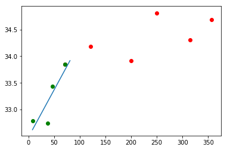

```python
plt.plot(x,y_)
plt.scatter(far_dist,far_temp,color='red')
plt.scatter(near_dist,near_temp,color='green')
```

```python
linear1 = LinearRegression()
linear1.fit(far_dist.reshape(-1,1),far_temp)
```

```
LinearRegression(copy_X=True, fit_intercept=True, n_jobs=1, normalize=False)
```

```python
xmin1,xmax1 = far_dist.min()-10,far_dist.max()
x1 = np.linspace(xmin1,xmax1,100).reshape(-1,1)
y1_ = linear1.predict(x1)
```

```
Text(0,0.5,'temperature')
```

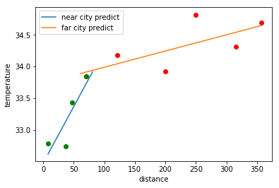

```python
plt.scatter(far_dist,far_temp,color='red')
plt.scatter(near_dist,near_temp,color='green')
plt.plot(x,y_,label='near city predict')
plt.plot(x1,y1_,label='far city predict')
plt.legend()

plt.xlabel('distance')
plt.ylabel('temperature')
```

最低湿度与海洋距离的关系

```
Text(0,0.5,'min_humidity')
```

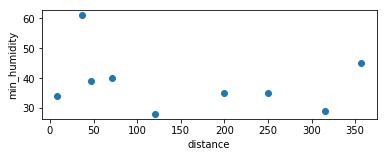

```python
min_humiditys = [city['humidity'].min() for city in city_list]
plt.figure(figsize=(6,2))
plt.scatter(dist,min_humiditys)
plt.xlabel('distance')
plt.ylabel('min_humidity')
```

最高湿度与海洋距离的关系

```
Text(0,0.5,'max_humidity')
```

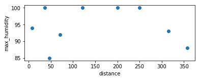

```python
min_humiditys = [city['humidity'].max() for city in city_list]
plt.figure(figsize=(6,2))
plt.scatter(dist,min_humiditys)
plt.xlabel('distance')
plt.ylabel('max_humidity')
```

平均湿度与海洋距离的关系

```
Text(0,0.5,'mean_humidity')
```

[figure not shown]

```python
mean_humiditys = [city['humidity'].mean() for city in city_list]
plt.figure(figsize=(6,2))
plt.scatter(dist,min_humiditys)
plt.xlabel('distance')
plt.ylabel('mean_humidity')
```

思考：模仿最高温度，得到平均湿度与海洋距离的回归曲线

```python
# 确定了一个线性回归模型
linear2 = LinearRegression()
```

```python
# 寻找因变量和自变量
far_city
near_city
```

```
array([ True, False, False, False,  True, False,  True, False,  True])
```

```python
mean_humiditys = np.array(mean_humiditys)
```

```python
far_humidity,near_humidity = mean_humiditys[far_city],mean_humiditys[near_city]

display(far_humidity,near_humidity)
display(far_dist,near_dist)
```

```
array([63.19117647, 59.14705882, 56.98484848, 63.13235294, 61.33823529,
       59.30882353])
```

```
array([61.30882353, 68.01515152, 61.33823529, 81.07462687])
```

```
array([357, 121, 250, 315,  71, 200], dtype=int64)
```

```
array([47,  8, 71, 37], dtype=int64)
```

```python
linear2.fit(near_dist.reshape(-1,1),near_humidity.reshape(-1,1))
```

```
LinearRegression(copy_X=True, fit_intercept=True, n_jobs=1, normalize=False)
```

```python
xmin,xmax = near_dist.min(),near_dist.max()+10
x = np.linspace(xmin,xmax,100).reshape(-1,1)
y_ = linear2.predict(x)
```

```python
linear3 = LinearRegression()
linear3.fit(far_dist.reshape(-1,1),far_humidity)
xmin1,xmax1 = far_dist.min()-10,far_dist.max()
x1 = np.linspace(xmin1,xmax1,100).reshape(-1,1)
y1_ = linear3.predict(x1)
```

[figure not shown]

```python
mean_humiditys = [city['humidity'].mean() for city in city_list]
plt.figure(figsize=(6,2))
plt.scatter(dist,min_humiditys)
plt.xlabel('distance')
plt.ylabel('mean_humidity')
plt.plot(x,y_,label='near_humidity_predict')
plt.plot(x1,y1_,label='far_humidity_predict')
plt.legend()
```

风向与风速的关系

```python
faenza.head(1)
```

|  | temp | humidity | pressure | description | dt | wind_speed | wind_deg | city | day | dist |
| --- | --- | --- | --- | --- | --- | --- | --- | --- | --- | --- |
| 0 | 29.4 | 83 | 1015 | moderate rain | 1436863177 | 3.62 | 94.001 | Faenza | 2015-07-14 10:39:37 | 37 |

```python
wind_speeds = [city['wind_speed'] for city in city_list]
wind_degs = [city['wind_deg'] for city in city_list]
city_humidity = [city['humidity'] for city in city_list]
```

在子图中，同时比较风向与湿度和风力的关系

```
Text(0.5,1,'wind_deg & wind_speed')
```

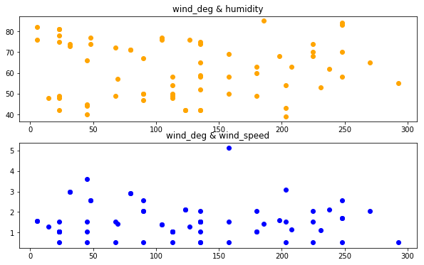

```python
plt.figure(figsize=(10,6))
axes1 = plt.subplot(211)
axes1.scatter(wind_degs[0],city_humidity[0],color='orange')
axes1.set_title('wind_deg & humidity')

axes2 = plt.subplot(212)
axes2.scatter(wind_degs[0],wind_speeds[0],color='blue')
axes2.set_title('wind_deg & wind_speed')
```

由于风向是360度，我们可以考虑使用玫瑰图（极坐标条形图）

```python
wind_degs
```

```
[0     180.00000
 1     135.00000
 2     113.00000
 3      90.00000
 4      68.00000
 5     113.00000
 6     113.00000
 7     180.00000
 8      90.00000
 9     135.00000
 10    113.00000
 11    135.00000
 12     90.00000
 13     68.00000
 14    135.00000
```

[output cut: 535 more lines]

```python
# 如何根据风向分组 假设我们要分8组
```

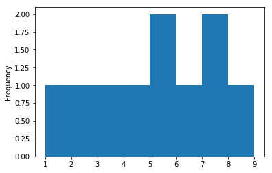

```python
s = Series(np.array([1,3,5,7,9,4,2,5,7,6]))
s.plot(kind='hist',bins=8)
```

```python
faenza
```

|  | temp | humidity | pressure | description | dt | wind_speed | wind_deg | city | day | dist |
| --- | --- | --- | --- | --- | --- | --- | --- | --- | --- | --- |
| 0 | 29.40 | 83 | 1015 | moderate rain | 1436863177 | 3.62 | 94.0010 | Faenza | 2015-07-14 10:39:37 | 37 |
| 1 | 30.12 | 78 | 1015 | moderate rain | 1436866759 | 3.10 | 80.0000 | Faenza | 2015-07-14 11:39:19 | 37 |
| 2 | 30.10 | 78 | 1015 | moderate rain | 1436870510 | 3.60 | 70.0000 | Faenza | 2015-07-14 12:41:50 | 37 |
| 3 | 30.75 | 74 | 1015 | moderate rain | 1436874099 | 4.60 | 90.0000 | Faenza | 2015-07-14 13:41:39 | 37 |
| 4 | 30.71 | 66 | 1015 | moderate rain | 1436877646 | 5.10 | 100.0000 | Faenza | 2015-07-14 14:40:46 | 37 |
| 5 | 31.29 | 66 | 1015 | moderate rain | 1436881330 | 5.70 | 90.0000 | Faenza | 2015-07-14 15:42:10 | 37 |
| 6 | 31.29 | 66 | 1014 | moderate rain | 1436884929 | 5.70 | 100.0000 | Faenza | 2015-07-14 16:42:09 | 37 |
| 7 | 30.40 | 66 | 1014 | moderate rain | 1436888513 | 5.70 | 120.0000 | Faenza | 2015-07-14 17:41:53 | 37 |
| 8 | 30.67 | 62 | 1014 | moderate rain | 1436892134 | 5.70 | 110.0000 | Faenza | 2015-07-14 18:42:14 | 37 |
| 9 | 29.68 | 65 | 1014 | moderate rain | 1436895723 | 4.60 | 120.0000 | Faenza | 2015-07-14 19:42:03 | 37 |
| 10 | 28.07 | 74 | 1014 | moderate rain | 1436899337 | 4.10 | 120.0000 | Faenza | 2015-07-14 20:42:17 | 37 |
| 11 | 27.10 | 83 | 1014 | moderate rain | 1436902943 | 2.60 | 110.0000 | Faenza | 2015-07-14 21:42:23 | 37 |
| 12 | 26.19 | 94 | 1014 | moderate rain | 1436906533 | 2.10 | 110.0000 | Faenza | 2015-07-14 22:42:13 | 37 |
| 13 | 25.51 | 94 | 1014 | moderate rain | 1436910150 | 2.41 | 116.5040 | Faenza | 2015-07-14 23:42:30 | 37 |
| 14 | 24.90 | 94 | 1015 | moderate rain | 1436913739 | 1.21 | 163.0010 | Faenza | 2015-07-15 00:42:19 | 37 |
| 15 | 24.46 | 94 | 1015 | moderate rain | 1436917313 | 1.00 | 240.0000 | Faenza | 2015-07-15 01:41:53 | 37 |
| 16 | 24.19 | 88 | 1015 | moderate rain | 1436920932 | 1.50 | 250.0000 | Faenza | 2015-07-15 02:42:12 | 37 |
| 17 | 23.99 | 94 | 1015 | Sky is Clear | 1436924427 | 0.50 | 250.0000 | Faenza | 2015-07-15 03:40:27 | 37 |
| 18 | 23.00 | 88 | 1015 | Sky is Clear | 1436928078 | 1.12 | 155.5030 | Faenza | 2015-07-15 04:41:18 | 37 |
| 19 | 23.00 | 88 | 1015 | Sky is Clear | 1436931718 | 1.12 | 155.5030 | Faenza | 2015-07-15 05:41:58 | 37 |
| 20 | 22.51 | 88 | 1015 | Sky is Clear | 1436935299 | 1.52 | 126.5010 | Faenza | 2015-07-15 06:41:39 | 37 |
| 21 | 23.01 | 94 | 1015 | Sky is Clear | 1436938883 | 1.52 | 126.5010 | Faenza | 2015-07-15 07:41:23 | 37 |
| 22 | 25.00 | 88 | 1016 | Sky is Clear | 1436942516 | 1.00 | 250.0000 | Faenza | 2015-07-15 08:41:56 | 37 |
| 23 | 27.51 | 88 | 1016 | Sky is Clear | 1436945951 | 2.57 | 99.0009 | Faenza | 2015-07-15 09:39:11 | 37 |
| 24 | 32.08 | 79 | 1010 | moderate rain | 1437730850 | 1.50 | 310.0000 | Faenza | 2015-07-24 11:40:50 | 37 |
| 25 | 32.40 | 75 | 1009 | moderate rain | 1437734493 | 3.60 | 40.0000 | Faenza | 2015-07-24 12:41:33 | 37 |
| 26 | 32.74 | 75 | 1009 | moderate rain | 1437738046 | 3.60 | 70.0000 | Faenza | 2015-07-24 13:40:46 | 37 |
| 27 | 32.70 | 79 | 1009 | moderate rain | 1437741579 | 5.10 | 70.0000 | Faenza | 2015-07-24 14:39:39 | 37 |
| 28 | 32.33 | 70 | 1008 | moderate rain | 1437745188 | 3.60 | 60.0000 | Faenza | 2015-07-24 15:39:48 | 37 |
| 29 | 32.40 | 74 | 1008 | moderate rain | 1437748777 | 2.60 | 80.0000 | Faenza | 2015-07-24 16:39:37 | 37 |
| ... | ... | ... | ... | ... | ... | ... | ... | ... | ... | ... |
| 37 | 27.22 | 100 | 1008 | moderate rain | 1437777556 | 1.50 | 250.0000 | Faenza | 2015-07-25 00:39:16 | 37 |
| 38 | 26.54 | 100 | 1007 | moderate rain | 1437781277 | 0.50 | 170.0000 | Faenza | 2015-07-25 01:41:17 | 37 |
| 39 | 25.93 | 100 | 1007 | moderate rain | 1437784850 | 1.00 | 250.0000 | Faenza | 2015-07-25 02:40:50 | 37 |
| 40 | 25.53 | 100 | 1007 | moderate rain | 1437788407 | 2.37 | 210.5040 | Faenza | 2015-07-25 03:40:07 | 37 |
| 41 | 25.01 | 94 | 1007 | moderate rain | 1437792027 | 3.32 | 224.0040 | Faenza | 2015-07-25 04:40:27 | 37 |
| 42 | 24.03 | 94 | 1007 | moderate rain | 1437795653 | 1.00 | 230.0000 | Faenza | 2015-07-25 05:40:53 | 37 |
| 43 | 24.77 | 94 | 1007 | moderate rain | 1437799262 | 1.00 | 230.0000 | Faenza | 2015-07-25 06:41:02 | 37 |
| 44 | 25.59 | 94 | 1008 | Sky is Clear | 1437802784 | 2.61 | 254.0010 | Faenza | 2015-07-25 07:39:44 | 37 |
| 45 | 27.23 | 83 | 1008 | Sky is Clear | 1437806426 | 2.61 | 254.0010 | Faenza | 2015-07-25 08:40:26 | 37 |
| 46 | 30.20 | 70 | 1008 | Sky is Clear | 1437809988 | 2.10 | 250.0000 | Faenza | 2015-07-25 09:39:48 | 37 |
| 47 | 31.12 | 70 | 1008 | moderate rain | 1437813634 | 3.60 | 260.0000 | Faenza | 2015-07-25 10:40:34 | 37 |
| 48 | 25.44 | 69 | 1018 | very heavy rain | 1435390925 | 1.29 | 14.5002 | Faenza | 2015-06-27 09:42:05 | 37 |
| 49 | 26.38 | 73 | 1017 | very heavy rain | 1435394243 | 2.10 | 100.0000 | Faenza | 2015-06-27 10:37:23 | 37 |
| 50 | 27.70 | 69 | 1017 | very heavy rain | 1435399019 | 3.10 | 120.0000 | Faenza | 2015-06-27 11:56:59 | 37 |
| 51 | 29.04 | 61 | 1016 | very heavy rain | 1435402422 | 3.10 | 110.0000 | Faenza | 2015-06-27 12:53:42 | 37 |
| 52 | 29.11 | 69 | 1016 | very heavy rain | 1435406058 | 3.60 | 110.0000 | Faenza | 2015-06-27 13:54:18 | 37 |
| 53 | 29.33 | 65 | 1015 | very heavy rain | 1435409704 | 5.70 | 110.0000 | Faenza | 2015-06-27 14:55:04 | 37 |
| 54 | 29.20 | 65 | 1014 | very heavy rain | 1435416898 | 5.10 | 110.0000 | Faenza | 2015-06-27 16:54:58 | 37 |
| 55 | 28.88 | 65 | 1014 | very heavy rain | 1435420542 | 6.20 | 120.0000 | Faenza | 2015-06-27 17:55:42 | 37 |
| 56 | 27.53 | 65 | 1014 | very heavy rain | 1435424296 | 6.70 | 120.0000 | Faenza | 2015-06-27 18:58:16 | 37 |
| 57 | 26.12 | 73 | 1013 | very heavy rain | 1435427936 | 6.20 | 120.0000 | Faenza | 2015-06-27 19:58:56 | 37 |
| 58 | 22.32 | 94 | 1015 | very heavy rain | 1435438357 | 2.60 | 90.0000 | Faenza | 2015-06-27 22:52:37 | 37 |
| 59 | 21.38 | 83 | 1016 | very heavy rain | 1435442241 | 5.70 | 90.0000 | Faenza | 2015-06-27 23:57:21 | 37 |
| 60 | 21.16 | 83 | 1016 | very heavy rain | 1435445863 | 2.10 | 210.0000 | Faenza | 2015-06-28 00:57:43 | 37 |
| 61 | 20.00 | 94 | 1016 | very heavy rain | 1435453232 | 1.39 | 218.5040 | Faenza | 2015-06-28 03:00:32 | 37 |
| 62 | 19.48 | 93 | 1016 | very heavy rain | 1435456487 | 2.10 | 330.0000 | Faenza | 2015-06-28 03:54:47 | 37 |
| 63 | 19.16 | 93 | 1016 | very heavy rain | 1435460042 | 1.50 | 320.0000 | Faenza | 2015-06-28 04:54:02 | 37 |
| 64 | 18.62 | 93 | 1016 | very heavy rain | 1435463880 | 0.50 | 300.0000 | Faenza | 2015-06-28 05:58:00 | 37 |
| 65 | 19.34 | 88 | 1016 | very heavy rain | 1435467179 | 0.50 | 270.0000 | Faenza | 2015-06-28 06:52:59 | 37 |
| 66 | 21.05 | 88 | 1016 | very heavy rain | 1435470851 | 2.10 | 260.0000 | Faenza | 2015-06-28 07:54:11 | 37 |

67 rows × 10 columns

```python
def draw_rose(city,feature1,feature2):
    bins = np.array([0,45,90,135,180,225,270,315])
    faenza_speeds = []
    for deg in bins:
        speed = city[feature1][(city[feature2] < deg+45) & (city[feature2] >= deg)].mean()
        faenza_speeds.append(speed)
    height = faenza_speeds
    index = np.array([0,45,90,135,180,225,270,315])
    index = index*np.pi/180
    plt.axes(polar=True)
    color = np.random.random(size=(8,3))
    plt.bar(x=index,height=height,color=color,align='edge')
    t = feature1 + '-' + feature2 + ' of ' + city['city'][0]
    plt.title(t)
```

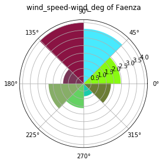

```python
draw_rose(faenza,'wind_speed','wind_deg')
```

首先自定义一个画图函数

计算米兰各个方向上的风速

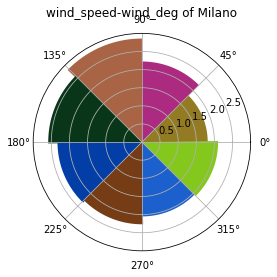

```python
draw_rose(milano,'wind_speed','wind_deg')
```

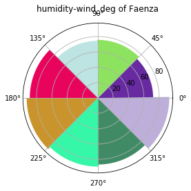

```python
draw_rose(faenza,'humidity','wind_deg')
```